# MLE Lab 2: Basic Regression and Graphs

## Coefficient plot

Let’s do a coefficient plot with the results from the robust and the OLS estimation. Although graphs are encouraged and easier to understand, always include the table results of your models, at least in your appendix. The code was adapted from [here](https://gist.github.com/dsparks/4332698)

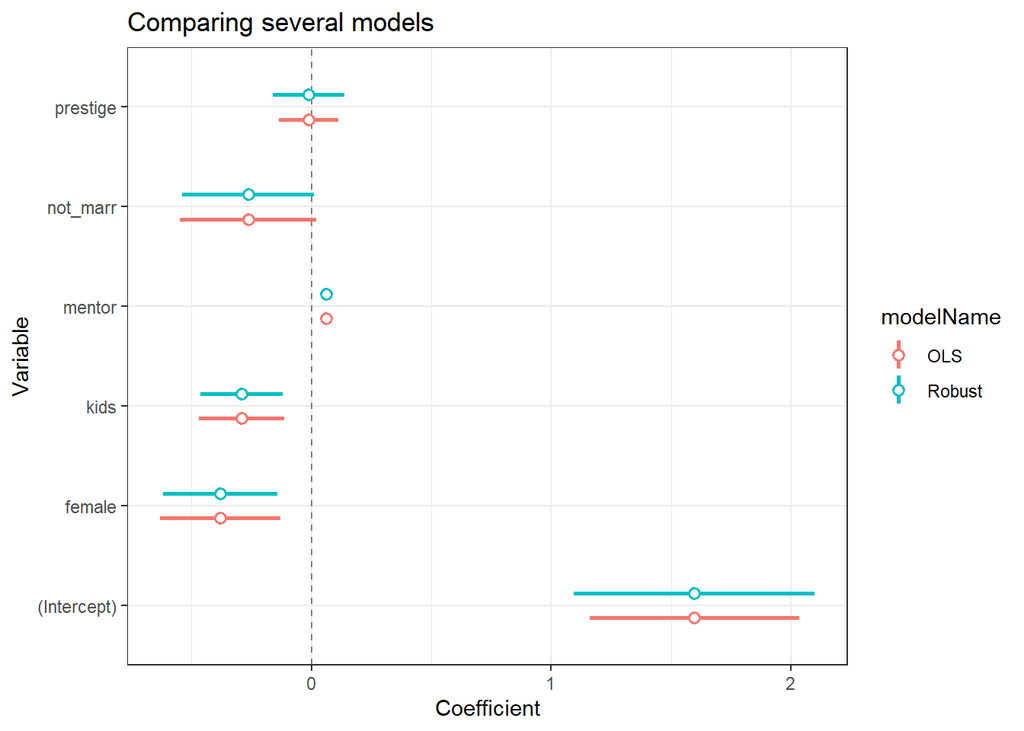

```r
# Put model estimates into temporary data.frames:
model1Frame <- data.frame(Variable = rownames(summary(mod1)$coef),
                          Coefficient = summary(mod1)$coef[, 1],
                          SE = summary(mod1)$coef[, 2],
                          modelName = "OLS")
model2Frame <- data.frame(Variable = rownames(summary(mod2)$coef),
                          Coefficient = summary(mod2)$coef[, 1],
                          SE = summary(mod2)$coef[, 2],
                          modelName = "Robust")

# Combine these data.frames
allModelFrame <- data.frame(rbind(model1Frame, model2Frame))  # etc.

# Specify the width of your confidence intervals
interval1 <- -qnorm((1-0.95)/2)  # 95% multiplier

# Plot
p1 <- ggplot(allModelFrame, aes(colour = modelName))                                               # create the area
p1 <- p1 + geom_hline(yintercept = 0, colour = gray(1/2), lty = 2)                                 # add the zero line
p1 <- p1 + geom_linerange(aes(x = Variable, ymin = Coefficient - SE*interval1,
                                ymax = Coefficient + SE*interval1),
                            lwd = 1, position = position_dodge(width = 1/2))                       # add the se
p1 <- p1 + geom_pointrange(aes(x = Variable, y = Coefficient, ymin = Coefficient - SE*interval1,
                                 ymax = Coefficient + SE*interval1),
                             lwd = 1/2, position = position_dodge(width = 1/2),
                             shape = 21, fill = "WHITE")                                           # add the point estimates
p1 <- p1 + coord_flip() + theme_bw()  + ggtitle("Comparing several models")                        # flip coordinates and give a title
p1
```

```r
# The trick to these is position_dodge() tha allows to include multiple coefficients at the same time
```

# **Additional Resources**

- I highly recommend Kieran Healy’s [book](https://socviz.co/index.html#preface) on Data Visualization using Ggplot
- [Positive definite and semi-definite matrices](https://www.youtube.com/watch?v=ttMZB5Gm_fM)
- [ggplot visualization examples](http://r-statistics.co/Top50-Ggplot2-Visualizations-MasterList-R-Code.html)
- [Properties for estimators](https://canvas.harvard.edu/courses/8498/modules/items/284319)
- [R-saquared visual explanation](https://www.machinelearningplus.com/wp-content/uploads/2017/03/R_Squared_Computation.png)